# Optimal Treatment Analysis

## Outcome Variable

**Outcome Variable:** whz

## Predictor Variables

**Intervention Variable:** impsan

**Adjustment Set:**

- arm
- sex
- W_mage
- meducyrs
- feducyrs
- hhwealth_quart
- hfoodsec
- W_mhtcm
- W_nrooms
- W_nchldlt5
- W_parity
- impfloor
- safeh20
- delta_W_mage
- delta_meducyrs
- delta_feducyrs
- delta_hhwealth_quart
- delta_hfoodsec
- delta_W_mhtcm
- delta_W_nrooms
- delta_W_nchldlt5
- delta_W_parity
- delta_impfloor
- delta_safeh20

## Stratifying Variables

The analysis was stratified on these variable(s):

- agecat
- studyid
- country

## Data Summary

| agecat | studyid | country | impsan | n_cell | n |
| --- | --- | --- | --- | --- | --- |
| Birth | ki0047075b-MAL-ED | BANGLADESH | 1 | 186 | 222 |
| Birth | ki0047075b-MAL-ED | BANGLADESH | 0 | 36 | 222 |
| Birth | ki0047075b-MAL-ED | BRAZIL | 1 | 163 | 167 |
| Birth | ki0047075b-MAL-ED | BRAZIL | 0 | 4 | 167 |
| Birth | ki0047075b-MAL-ED | INDIA | 1 | 90 | 188 |
| Birth | ki0047075b-MAL-ED | INDIA | 0 | 98 | 188 |
| Birth | ki0047075b-MAL-ED | NEPAL | 1 | 165 | 166 |
| Birth | ki0047075b-MAL-ED | NEPAL | 0 | 1 | 166 |
| Birth | ki0047075b-MAL-ED | PERU | 1 | 60 | 243 |
| Birth | ki0047075b-MAL-ED | PERU | 0 | 183 | 243 |
| Birth | ki0047075b-MAL-ED | SOUTH AFRICA | 1 | 2 | 211 |
| Birth | ki0047075b-MAL-ED | SOUTH AFRICA | 0 | 209 | 211 |
| Birth | ki0047075b-MAL-ED | TANZANIA, UNITED REPUBLIC OF | 1 | 0 | 109 |
| Birth | ki0047075b-MAL-ED | TANZANIA, UNITED REPUBLIC OF | 0 | 109 | 109 |
| Birth | ki1017093-NIH-Birth | BANGLADESH | 1 | 9 | 28 |
| Birth | ki1017093-NIH-Birth | BANGLADESH | 0 | 19 | 28 |
| Birth | ki1017093c-NIH-Crypto | BANGLADESH | 1 | 21 | 23 |
| Birth | ki1017093c-NIH-Crypto | BANGLADESH | 0 | 2 | 23 |
| Birth | ki1114097-CONTENT | PERU | 1 | 1 | 2 |
| Birth | ki1114097-CONTENT | PERU | 0 | 1 | 2 |
| Birth | ki1135781-COHORTS | GUATEMALA | 1 | 43 | 449 |
| Birth | ki1135781-COHORTS | GUATEMALA | 0 | 406 | 449 |
| Birth | ki1135781-COHORTS | INDIA | 1 | 1685 | 4461 |
| Birth | ki1135781-COHORTS | INDIA | 0 | 2776 | 4461 |
| Birth | ki1135781-COHORTS | PHILIPPINES | 1 | 177 | 1126 |
| Birth | ki1135781-COHORTS | PHILIPPINES | 0 | 949 | 1126 |
| Birth | kiGH5241-JiVitA-3 | BANGLADESH | 1 | 10724 | 15689 |
| Birth | kiGH5241-JiVitA-3 | BANGLADESH | 0 | 4965 | 15689 |
| Birth | kiGH5241-JiVitA-4 | BANGLADESH | 1 | 503 | 683 |
| Birth | kiGH5241-JiVitA-4 | BANGLADESH | 0 | 180 | 683 |

[output cut: 68 more lines]

The following strata were considered:

- agecat: 24 months, studyid: ki0047075b-MAL-ED, country: BANGLADESH
- agecat: 24 months, studyid: ki0047075b-MAL-ED, country: BRAZIL
- agecat: 24 months, studyid: ki0047075b-MAL-ED, country: INDIA
- agecat: 24 months, studyid: ki0047075b-MAL-ED, country: NEPAL
- agecat: 24 months, studyid: ki0047075b-MAL-ED, country: PERU
- agecat: 24 months, studyid: ki0047075b-MAL-ED, country: SOUTH AFRICA
- agecat: 24 months, studyid: ki0047075b-MAL-ED, country: TANZANIA, UNITED REPUBLIC OF
- agecat: 24 months, studyid: ki1017093-NIH-Birth, country: BANGLADESH
- agecat: 24 months, studyid: ki1017093b-PROVIDE, country: BANGLADESH
- agecat: 24 months, studyid: ki1017093c-NIH-Crypto, country: BANGLADESH
- agecat: 24 months, studyid: ki1114097-CONTENT, country: PERU
- agecat: 24 months, studyid: ki1135781-COHORTS, country: GUATEMALA
- agecat: 24 months, studyid: ki1135781-COHORTS, country: INDIA
- agecat: 24 months, studyid: ki1135781-COHORTS, country: PHILIPPINES
- agecat: 24 months, studyid: ki1148112-LCNI-5, country: MALAWI
- agecat: 24 months, studyid: kiGH5241-JiVitA-3, country: BANGLADESH
- agecat: 24 months, studyid: kiGH5241-JiVitA-4, country: BANGLADESH
- agecat: 6 months, studyid: ki0047075b-MAL-ED, country: BANGLADESH
- agecat: 6 months, studyid: ki0047075b-MAL-ED, country: BRAZIL
- agecat: 6 months, studyid: ki0047075b-MAL-ED, country: INDIA
- agecat: 6 months, studyid: ki0047075b-MAL-ED, country: NEPAL
- agecat: 6 months, studyid: ki0047075b-MAL-ED, country: PERU
- agecat: 6 months, studyid: ki0047075b-MAL-ED, country: SOUTH AFRICA
- agecat: 6 months, studyid: ki0047075b-MAL-ED, country: TANZANIA, UNITED REPUBLIC OF
- agecat: 6 months, studyid: ki1017093-NIH-Birth, country: BANGLADESH
- agecat: 6 months, studyid: ki1017093b-PROVIDE, country: BANGLADESH
- agecat: 6 months, studyid: ki1017093c-NIH-Crypto, country: BANGLADESH
- agecat: 6 months, studyid: ki1114097-CONTENT, country: PERU
- agecat: 6 months, studyid: ki1135781-COHORTS, country: GUATEMALA
- agecat: 6 months, studyid: ki1135781-COHORTS, country: INDIA
- agecat: 6 months, studyid: ki1135781-COHORTS, country: PHILIPPINES
- agecat: 6 months, studyid: ki1148112-LCNI-5, country: MALAWI
- agecat: 6 months, studyid: kiGH5241-JiVitA-3, country: BANGLADESH
- agecat: 6 months, studyid: kiGH5241-JiVitA-4, country: BANGLADESH
- agecat: Birth, studyid: ki0047075b-MAL-ED, country: BANGLADESH
- agecat: Birth, studyid: ki0047075b-MAL-ED, country: BRAZIL
- agecat: Birth, studyid: ki0047075b-MAL-ED, country: INDIA
- agecat: Birth, studyid: ki0047075b-MAL-ED, country: NEPAL
- agecat: Birth, studyid: ki0047075b-MAL-ED, country: PERU
- agecat: Birth, studyid: ki0047075b-MAL-ED, country: SOUTH AFRICA
- agecat: Birth, studyid: ki0047075b-MAL-ED, country: TANZANIA, UNITED REPUBLIC OF
- agecat: Birth, studyid: ki1017093-NIH-Birth, country: BANGLADESH
- agecat: Birth, studyid: ki1017093c-NIH-Crypto, country: BANGLADESH
- agecat: Birth, studyid: ki1114097-CONTENT, country: PERU
- agecat: Birth, studyid: ki1135781-COHORTS, country: GUATEMALA
- agecat: Birth, studyid: ki1135781-COHORTS, country: INDIA
- agecat: Birth, studyid: ki1135781-COHORTS, country: PHILIPPINES
- agecat: Birth, studyid: kiGH5241-JiVitA-3, country: BANGLADESH
- agecat: Birth, studyid: kiGH5241-JiVitA-4, country: BANGLADESH

### Dropped Strata

Some strata were dropped due to rare outcomes:

- agecat: Birth, studyid: ki0047075b-MAL-ED, country: BRAZIL
- agecat: Birth, studyid: ki0047075b-MAL-ED, country: NEPAL
- agecat: Birth, studyid: ki0047075b-MAL-ED, country: SOUTH AFRICA
- agecat: Birth, studyid: ki0047075b-MAL-ED, country: TANZANIA, UNITED REPUBLIC OF
- agecat: Birth, studyid: ki1017093c-NIH-Crypto, country: BANGLADESH
- agecat: Birth, studyid: ki1114097-CONTENT, country: PERU
- agecat: 6 months, studyid: ki0047075b-MAL-ED, country: BRAZIL
- agecat: 6 months, studyid: ki0047075b-MAL-ED, country: NEPAL
- agecat: 6 months, studyid: ki0047075b-MAL-ED, country: SOUTH AFRICA
- agecat: 6 months, studyid: ki0047075b-MAL-ED, country: TANZANIA, UNITED REPUBLIC OF
- agecat: 6 months, studyid: ki1148112-LCNI-5, country: MALAWI
- agecat: 24 months, studyid: ki0047075b-MAL-ED, country: BRAZIL
- agecat: 24 months, studyid: ki0047075b-MAL-ED, country: NEPAL
- agecat: 24 months, studyid: ki0047075b-MAL-ED, country: SOUTH AFRICA
- agecat: 24 months, studyid: ki0047075b-MAL-ED, country: TANZANIA, UNITED REPUBLIC OF
- agecat: 24 months, studyid: ki1148112-LCNI-5, country: MALAWI

## Methods Detail

We’re interested in the causal parameters $E[Y_a]$ for all values of $a \in \mathcal{A}$. These parameters represent the mean outcome if, possibly contrary to fact, we intervened to set all units to have $A=a$. Under the randomization and positivity assumptions, these are identified by the statistical parameters $\psi_a=E_W[E_{Y|A,W}(Y|A=a,W)]$. In addition, we’re interested in the mean of $Y$, $E[Y]$ under no intervention (the observed mean). We will estimate these parameters by using SuperLearner to fit the relevant likelihood factors – $E_{Y|A,W}(Y|A=a,W)$ and $p(A=a|W)$, and then updating our likelihood fit using a joint TMLE.

For unadjusted analyses ($W=\{\}$), initial likelihoods were estimated using Lrnr_glm to estimate the simple $E(Y|A)$ and Lrnr_mean to estimate $p(A)$. For adjusted analyses, a small library containing Lrnr_glmnet, Lrnr_xgboost, and Lrnr_mean was used.

Having estimated these parameters, we will then use the delta method to estimate relative risks and attributable risks relative to a prespecified baseline level of $A$.

# Results Detail

## Results Plots

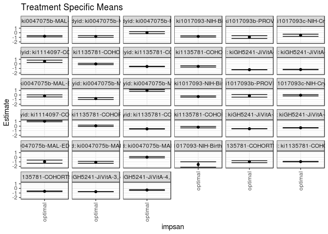

## Results Table

### Parameter: TSM

| agecat | studyid | country | intervention_level | baseline_level | estimate | ci_lower | ci_upper |
| --- | --- | --- | --- | --- | --- | --- | --- |
| Birth | ki0047075b-MAL-ED | BANGLADESH | optimal | observed | -0.9659511 | -1.3125076 | -0.6193946 |
| Birth | ki0047075b-MAL-ED | INDIA | optimal | observed | -1.0966348 | -1.3103299 | -0.8829397 |
| Birth | ki0047075b-MAL-ED | PERU | optimal | observed | 0.0094809 | -0.1327851 | 0.1517469 |
| Birth | ki1017093-NIH-Birth | BANGLADESH | optimal | observed | -1.5757448 | -2.1679327 | -0.9835568 |
| Birth | ki1135781-COHORTS | GUATEMALA | optimal | observed | -0.9597634 | -1.1801591 | -0.7393676 |
| Birth | ki1135781-COHORTS | INDIA | optimal | observed | -0.9484460 | -1.0098988 | -0.8869932 |
| Birth | ki1135781-COHORTS | PHILIPPINES | optimal | observed | -0.6358237 | -0.7214751 | -0.5501722 |
| Birth | kiGH5241-JiVitA-3 | BANGLADESH | optimal | observed | -0.7131842 | -0.7377027 | -0.6886657 |
| Birth | kiGH5241-JiVitA-4 | BANGLADESH | optimal | observed | -0.3483772 | -0.4430923 | -0.2536621 |
| 6 months | ki0047075b-MAL-ED | BANGLADESH | optimal | observed | -0.1917461 | -0.4171321 | 0.0336399 |
| 6 months | ki0047075b-MAL-ED | INDIA | optimal | observed | -0.7820803 | -0.9859006 | -0.5782600 |
| 6 months | ki0047075b-MAL-ED | PERU | optimal | observed | 0.9818189 | 0.7874822 | 1.1761556 |
| 6 months | ki1017093-NIH-Birth | BANGLADESH | optimal | observed | -0.3364250 | -0.4774304 | -0.1954196 |
| 6 months | ki1017093b-PROVIDE | BANGLADESH | optimal | observed | -0.1819276 | -0.4689270 | 0.1050717 |
| 6 months | ki1017093c-NIH-Crypto | BANGLADESH | optimal | observed | -0.0562095 | -0.2034382 | 0.0910193 |
| 6 months | ki1114097-CONTENT | PERU | optimal | observed | 1.0740849 | 0.9519310 | 1.1962387 |
| 6 months | ki1135781-COHORTS | GUATEMALA | optimal | observed | 0.0753301 | -0.0704798 | 0.2211400 |
| 6 months | ki1135781-COHORTS | INDIA | optimal | observed | -0.5976434 | -0.6524520 | -0.5428347 |
| 6 months | ki1135781-COHORTS | PHILIPPINES | optimal | observed | -0.2298722 | -0.3840977 | -0.0756467 |
| 6 months | kiGH5241-JiVitA-3 | BANGLADESH | optimal | observed | -0.5720387 | -0.5949935 | -0.5490840 |
| 6 months | kiGH5241-JiVitA-4 | BANGLADESH | optimal | observed | -0.3630619 | -0.4058382 | -0.3202855 |
| 24 months | ki0047075b-MAL-ED | BANGLADESH | optimal | observed | -0.7672480 | -0.8991810 | -0.6353151 |
| 24 months | ki0047075b-MAL-ED | INDIA | optimal | observed | -0.8096945 | -0.9940178 | -0.6253711 |
| 24 months | ki0047075b-MAL-ED | PERU | optimal | observed | 0.0217486 | -0.2078045 | 0.2513017 |
| 24 months | ki1017093-NIH-Birth | BANGLADESH | optimal | observed | -0.8067360 | -0.9489115 | -0.6645605 |
| 24 months | ki1017093b-PROVIDE | BANGLADESH | optimal | observed | -0.9431867 | -1.2369318 | -0.6494416 |
| 24 months | ki1017093c-NIH-Crypto | BANGLADESH | optimal | observed | -0.5528872 | -0.7897419 | -0.3160325 |
| 24 months | ki1114097-CONTENT | PERU | optimal | observed | 0.5453732 | 0.2836786 | 0.8070679 |
| 24 months | ki1135781-COHORTS | GUATEMALA | optimal | observed | -0.0140661 | -0.1601168 | 0.1319845 |
| 24 months | ki1135781-COHORTS | INDIA | optimal | observed | -0.5680156 | -0.6210129 | -0.5150183 |
| 24 months | ki1135781-COHORTS | PHILIPPINES | optimal | observed | -0.5555390 | -0.7044187 | -0.4066594 |
| 24 months | kiGH5241-JiVitA-3 | BANGLADESH | optimal | observed | -1.2731280 | -1.3012357 | -1.2450203 |
| 24 months | kiGH5241-JiVitA-4 | BANGLADESH | optimal | observed | -1.2352290 | -1.2805255 | -1.1899325 |

### Parameter: E(Y)

| agecat | studyid | country | intervention_level | baseline_level | estimate | ci_lower | ci_upper |
| --- | --- | --- | --- | --- | --- | --- | --- |
| Birth | ki0047075b-MAL-ED | BANGLADESH | observed | observed | -0.9902252 | -1.1311070 | -0.8493435 |
| Birth | ki0047075b-MAL-ED | INDIA | observed | observed | -1.0536702 | -1.1965043 | -0.9108361 |
| Birth | ki0047075b-MAL-ED | PERU | observed | observed | -0.0315638 | -0.1495606 | 0.0864330 |
| Birth | ki1017093-NIH-Birth | BANGLADESH | observed | observed | -1.4239286 | -1.7688028 | -1.0790544 |
| Birth | ki1135781-COHORTS | GUATEMALA | observed | observed | -0.9294432 | -1.0701697 | -0.7887168 |
| Birth | ki1135781-COHORTS | INDIA | observed | observed | -0.9771733 | -1.0119896 | -0.9423570 |
| Birth | ki1135781-COHORTS | PHILIPPINES | observed | observed | -0.6841030 | -0.7582767 | -0.6099293 |
| Birth | kiGH5241-JiVitA-3 | BANGLADESH | observed | observed | -0.7238913 | -0.7437437 | -0.7040388 |
| Birth | kiGH5241-JiVitA-4 | BANGLADESH | observed | observed | -0.3683163 | -0.4490504 | -0.2875821 |
| 6 months | ki0047075b-MAL-ED | BANGLADESH | observed | observed | -0.1354618 | -0.2647919 | -0.0061317 |
| 6 months | ki0047075b-MAL-ED | INDIA | observed | observed | -0.7004578 | -0.8268704 | -0.5740452 |
| 6 months | ki0047075b-MAL-ED | PERU | observed | observed | 1.0376236 | 0.9141918 | 1.1610554 |
| 6 months | ki1017093-NIH-Birth | BANGLADESH | observed | observed | -0.4389101 | -0.5279432 | -0.3498771 |
| 6 months | ki1017093b-PROVIDE | BANGLADESH | observed | observed | -0.2080201 | -0.2927357 | -0.1233045 |
| 6 months | ki1017093c-NIH-Crypto | BANGLADESH | observed | observed | 0.0336790 | -0.0458848 | 0.1132428 |
| 6 months | ki1114097-CONTENT | PERU | observed | observed | 1.0684318 | 0.9515274 | 1.1853362 |
| 6 months | ki1135781-COHORTS | GUATEMALA | observed | observed | 0.1458511 | 0.0589571 | 0.2327450 |
| 6 months | ki1135781-COHORTS | INDIA | observed | observed | -0.7104855 | -0.7428053 | -0.6781657 |
| 6 months | ki1135781-COHORTS | PHILIPPINES | observed | observed | -0.2830286 | -0.3471028 | -0.2189545 |
| 6 months | kiGH5241-JiVitA-3 | BANGLADESH | observed | observed | -0.5931476 | -0.6127125 | -0.5735828 |
| 6 months | kiGH5241-JiVitA-4 | BANGLADESH | observed | observed | -0.3901595 | -0.4274150 | -0.3529041 |
| 24 months | ki0047075b-MAL-ED | BANGLADESH | observed | observed | -0.8208255 | -0.9429246 | -0.6987264 |
| 24 months | ki0047075b-MAL-ED | INDIA | observed | observed | -0.9496667 | -1.0657716 | -0.8335618 |
| 24 months | ki0047075b-MAL-ED | PERU | observed | observed | 0.1064286 | -0.0147106 | 0.2275677 |
| 24 months | ki1017093-NIH-Birth | BANGLADESH | observed | observed | -0.9115790 | -1.0095022 | -0.8136559 |
| 24 months | ki1017093b-PROVIDE | BANGLADESH | observed | observed | -0.8896187 | -0.9726240 | -0.8066134 |
| 24 months | ki1017093c-NIH-Crypto | BANGLADESH | observed | observed | -0.6115706 | -0.7075788 | -0.5155624 |
| 24 months | ki1114097-CONTENT | PERU | observed | observed | 0.5668293 | 0.4302437 | 0.7034148 |
| 24 months | ki1135781-COHORTS | GUATEMALA | observed | observed | -0.2861905 | -0.3461594 | -0.2262216 |
| 24 months | ki1135781-COHORTS | INDIA | observed | observed | -0.6606874 | -0.6938402 | -0.6275347 |
| 24 months | ki1135781-COHORTS | PHILIPPINES | observed | observed | -0.6564149 | -0.7144543 | -0.5983756 |
| 24 months | kiGH5241-JiVitA-3 | BANGLADESH | observed | observed | -1.2970418 | -1.3203361 | -1.2737475 |
| 24 months | kiGH5241-JiVitA-4 | BANGLADESH | observed | observed | -1.2231776 | -1.2550332 | -1.1913220 |

### Parameter: PAR

| agecat | studyid | country | intervention_level | baseline_level | estimate | ci_lower | ci_upper |
| --- | --- | --- | --- | --- | --- | --- | --- |
| Birth | ki0047075b-MAL-ED | BANGLADESH | optimal | observed | -0.0242742 | -0.3387604 | 0.2902121 |
| Birth | ki0047075b-MAL-ED | INDIA | optimal | observed | 0.0429646 | -0.1081326 | 0.1940618 |
| Birth | ki0047075b-MAL-ED | PERU | optimal | observed | -0.0410447 | -0.1053339 | 0.0232446 |
| Birth | ki1017093-NIH-Birth | BANGLADESH | optimal | observed | 0.1518162 | -0.2104036 | 0.5140360 |
| Birth | ki1135781-COHORTS | GUATEMALA | optimal | observed | 0.0303201 | -0.1431229 | 0.2037631 |
| Birth | ki1135781-COHORTS | INDIA | optimal | observed | -0.0287273 | -0.0779714 | 0.0205168 |
| Birth | ki1135781-COHORTS | PHILIPPINES | optimal | observed | -0.0482793 | -0.0885436 | -0.0080151 |
| Birth | kiGH5241-JiVitA-3 | BANGLADESH | optimal | observed | -0.0107071 | -0.0233062 | 0.0018921 |
| Birth | kiGH5241-JiVitA-4 | BANGLADESH | optimal | observed | -0.0199390 | -0.0690847 | 0.0292066 |
| 6 months | ki0047075b-MAL-ED | BANGLADESH | optimal | observed | 0.0562843 | -0.1461221 | 0.2586907 |
| 6 months | ki0047075b-MAL-ED | INDIA | optimal | observed | 0.0816225 | -0.0585816 | 0.2218266 |
| 6 months | ki0047075b-MAL-ED | PERU | optimal | observed | 0.0558047 | -0.0951896 | 0.2067989 |
| 6 months | ki1017093-NIH-Birth | BANGLADESH | optimal | observed | -0.1024851 | -0.2153145 | 0.0103442 |
| 6 months | ki1017093b-PROVIDE | BANGLADESH | optimal | observed | -0.0260925 | -0.3064327 | 0.2542477 |
| 6 months | ki1017093c-NIH-Crypto | BANGLADESH | optimal | observed | 0.0898884 | -0.0314504 | 0.2112273 |
| 6 months | ki1114097-CONTENT | PERU | optimal | observed | -0.0056531 | -0.0327054 | 0.0213993 |
| 6 months | ki1135781-COHORTS | GUATEMALA | optimal | observed | 0.0705210 | -0.0593106 | 0.2003526 |
| 6 months | ki1135781-COHORTS | INDIA | optimal | observed | -0.1128421 | -0.1583528 | -0.0673315 |
| 6 months | ki1135781-COHORTS | PHILIPPINES | optimal | observed | -0.0531564 | -0.1961351 | 0.0898222 |
| 6 months | kiGH5241-JiVitA-3 | BANGLADESH | optimal | observed | -0.0211089 | -0.0328505 | -0.0093673 |
| 6 months | kiGH5241-JiVitA-4 | BANGLADESH | optimal | observed | -0.0270977 | -0.0486954 | -0.0054999 |
| 24 months | ki0047075b-MAL-ED | BANGLADESH | optimal | observed | -0.0535774 | -0.1056579 | -0.0014970 |
| 24 months | ki0047075b-MAL-ED | INDIA | optimal | observed | -0.1399722 | -0.2708794 | -0.0090650 |
| 24 months | ki0047075b-MAL-ED | PERU | optimal | observed | 0.0846800 | -0.1063961 | 0.2757561 |
| 24 months | ki1017093-NIH-Birth | BANGLADESH | optimal | observed | -0.1048430 | -0.2150524 | 0.0053663 |
| 24 months | ki1017093b-PROVIDE | BANGLADESH | optimal | observed | 0.0535680 | -0.2376032 | 0.3447391 |
| 24 months | ki1017093c-NIH-Crypto | BANGLADESH | optimal | observed | -0.0586834 | -0.2780022 | 0.1606354 |
| 24 months | ki1114097-CONTENT | PERU | optimal | observed | 0.0214560 | -0.2466317 | 0.2895438 |
| 24 months | ki1135781-COHORTS | GUATEMALA | optimal | observed | -0.2721243 | -0.4121701 | -0.1320785 |
| 24 months | ki1135781-COHORTS | INDIA | optimal | observed | -0.0926718 | -0.1346099 | -0.0507338 |
| 24 months | ki1135781-COHORTS | PHILIPPINES | optimal | observed | -0.1008759 | -0.2409451 | 0.0391934 |
| 24 months | kiGH5241-JiVitA-3 | BANGLADESH | optimal | observed | -0.0239138 | -0.0397327 | -0.0080950 |
| 24 months | kiGH5241-JiVitA-4 | BANGLADESH | optimal | observed | 0.0120514 | -0.0211959 | 0.0452987 |